**Projet IA HumanForYou**

[figure not shown]

GIRARD-TISSIER Ugo | GISLARD Enzo | GUESMIA Abdelrahmane | CASENOVE Antoine

# Sommaire

- Introduction
- Préparation des données

# 1. Introduction

L'entreprise HumanForYou subit un turn-over d'environ 15% de ses employés (4000) chaque années.

La direction trouve que ce niveau de turn-over n'est pas bon pour l'entreprise car :

- Les projets prennent du retard.
- Un service de ressources humaines de taille conséquente.
- Temps perdu à l'arrivée des nouveaux employés.

#### Objectif du projet :

- Déterminer les facteurs de turn-over
- Proposer des modèles afin d'avoir des pistes d'amélioration pour donner à leurs employés l'envie de rester.

#### Solution réalisée :

- Modèle prédictif de classification binaire
- Étude des facteurs de turn-over selon notre modèle

# 2. Préparation des données

### A. Chargement des jeux de données

```python
general_data.head(2).style
```

|  | Age | Attrition | BusinessTravel | Department | DistanceFromHome | Education | EducationField | EmployeeCount | EmployeeID | Gender | JobLevel | JobRole | MaritalStatus | MonthlyIncome | NumCompaniesWorked | Over18 | PercentSalaryHike | StandardHours | StockOptionLevel | TotalWorkingYears | TrainingTimesLastYear | YearsAtCompany | YearsSinceLastPromotion | YearsWithCurrManager |
| --- | --- | --- | --- | --- | --- | --- | --- | --- | --- | --- | --- | --- | --- | --- | --- | --- | --- | --- | --- | --- | --- | --- | --- | --- |
| 0 | 51 | No | Travel_Rarely | Sales | 6 | 2 | Life Sciences | 1 | 1 | Female | 1 | Healthcare Representative | Married | 131160 | 1.000000 | Y | 11 | 8 | 0 | 1.000000 | 6 | 1 | 0 | 0 |
| 1 | 31 | Yes | Travel_Frequently | Research & Development | 10 | 1 | Life Sciences | 1 | 2 | Female | 1 | Research Scientist | Single | 41890 | 0.000000 | Y | 23 | 8 | 1 | 6.000000 | 3 | 5 | 1 | 4 |

```python
manager_survey_data.head(2).style
```

|  | EmployeeID | JobInvolvement | PerformanceRating |
| --- | --- | --- | --- |
| 0 | 1 | 3 | 3 |
| 1 | 2 | 2 | 4 |

```python
employee_survey_data.head(2).style
```

|  | EmployeeID | EnvironmentSatisfaction | JobSatisfaction | WorkLifeBalance |
| --- | --- | --- | --- | --- |
| 0 | 1 | 3.000000 | 4.000000 | 2.000000 |
| 1 | 2 | 3.000000 | 2.000000 | 4.000000 |

```python
in_time_data.head(2).style
```

|  | Unnamed: 0 | 2015-01-01 | 2015-01-02 | 2015-01-05 | 2015-01-06 | 2015-01-07 | 2015-01-08 | 2015-01-09 | 2015-01-12 | 2015-01-13 | 2015-01-14 | 2015-01-15 | 2015-01-16 | 2015-01-19 | 2015-01-20 | 2015-01-21 | 2015-01-22 | 2015-01-23 | 2015-01-26 | 2015-01-27 | 2015-01-28 | 2015-01-29 | 2015-01-30 | 2015-02-02 | 2015-02-03 | 2015-02-04 | 2015-02-05 | 2015-02-06 | 2015-02-09 | … |
| --- | --- | --- | --- | --- | --- | --- | --- | --- | --- | --- | --- | --- | --- | --- | --- | --- | --- | --- | --- | --- | --- | --- | --- | --- | --- | --- | --- | --- | --- | --- |
| 0 | 1 | nan | 2015-01-02 09:43:45 | 2015-01-05 10:08:48 | 2015-01-06 09:54:26 | 2015-01-07 09:34:31 | 2015-01-08 09:51:09 | 2015-01-09 10:09:25 | 2015-01-12 09:42:53 | 2015-01-13 10:13:06 | nan | 2015-01-15 10:01:24 | 2015-01-16 10:19:08 | nan | 2015-01-20 09:50:34 | 2015-01-21 09:49:42 | 2015-01-22 09:47:45 | 2015-01-23 09:23:44 | nan | 2015-01-27 09:50:37 | 2015-01-28 09:56:13 | 2015-01-29 09:53:47 | 2015-01-30 10:09:26 | 2015-02-02 09:38:43 | 2015-02-03 10:23:38 | 2015-02-04 09:48:37 | 2015-02-05 09:52:36 | 2015-02-06 09:53:23 | 2015-02-09 10:01:45 | … |
| 1 | 2 | nan | 2015-01-02 10:15:44 | 2015-01-05 10:21:05 | nan | 2015-01-07 09:45:17 | 2015-01-08 10:09:04 | 2015-01-09 09:43:26 | 2015-01-12 10:00:07 | 2015-01-13 10:43:29 | nan | 2015-01-15 09:37:57 | 2015-01-16 09:57:18 | 2015-01-19 10:23:43 | 2015-01-20 09:29:03 | 2015-01-21 09:46:45 | 2015-01-22 10:03:51 | 2015-01-23 09:20:06 | nan | 2015-01-27 10:07:48 | 2015-01-28 10:08:25 | 2015-01-29 09:52:04 | 2015-01-30 09:49:49 | 2015-02-02 10:07:26 | 2015-02-03 09:55:45 | 2015-02-04 10:25:41 | 2015-02-05 10:05:11 | 2015-02-06 09:12:39 | nan | … |

```python
out_time_data.head(2).style
```

|  | Unnamed: 0 | 2015-01-01 | 2015-01-02 | 2015-01-05 | 2015-01-06 | 2015-01-07 | 2015-01-08 | 2015-01-09 | 2015-01-12 | 2015-01-13 | 2015-01-14 | 2015-01-15 | 2015-01-16 | 2015-01-19 | 2015-01-20 | 2015-01-21 | 2015-01-22 | 2015-01-23 | 2015-01-26 | 2015-01-27 | 2015-01-28 | 2015-01-29 | 2015-01-30 | 2015-02-02 | 2015-02-03 | 2015-02-04 | 2015-02-05 | 2015-02-06 | 2015-02-09 | … |
| --- | --- | --- | --- | --- | --- | --- | --- | --- | --- | --- | --- | --- | --- | --- | --- | --- | --- | --- | --- | --- | --- | --- | --- | --- | --- | --- | --- | --- | --- | --- |
| 0 | 1 | nan | 2015-01-02 16:56:15 | 2015-01-05 17:20:11 | 2015-01-06 17:19:05 | 2015-01-07 16:34:55 | 2015-01-08 17:08:32 | 2015-01-09 17:38:29 | 2015-01-12 16:58:39 | 2015-01-13 18:02:58 | nan | 2015-01-15 17:22:13 | 2015-01-16 17:35:11 | nan | 2015-01-20 16:37:07 | 2015-01-21 16:55:24 | 2015-01-22 16:50:47 | 2015-01-23 17:00:01 | nan | 2015-01-27 17:28:22 | 2015-01-28 17:03:21 | 2015-01-29 17:18:36 | 2015-01-30 17:00:25 | 2015-02-02 16:32:49 | 2015-02-03 17:35:49 | 2015-02-04 17:24:56 | 2015-02-05 17:26:31 | 2015-02-06 17:21:35 | 2015-02-09 17:37:50 | … |
| 1 | 2 | nan | 2015-01-02 18:22:17 | 2015-01-05 17:48:22 | nan | 2015-01-07 17:09:06 | 2015-01-08 17:34:04 | 2015-01-09 16:52:29 | 2015-01-12 17:36:48 | 2015-01-13 18:00:13 | nan | 2015-01-15 17:14:44 | 2015-01-16 17:40:57 | 2015-01-19 17:58:22 | 2015-01-20 17:05:13 | 2015-01-21 17:41:05 | 2015-01-22 17:26:26 | 2015-01-23 17:06:50 | nan | 2015-01-27 17:35:50 | 2015-01-28 17:19:48 | 2015-01-29 17:07:38 | 2015-01-30 16:53:22 | 2015-02-02 17:45:18 | 2015-02-03 17:33:42 | 2015-02-04 18:04:20 | 2015-02-05 17:43:25 | 2015-02-06 17:06:42 | nan | … |

### B. Construction d'un unique dataset

```python
dataset.head().style
```

|  | Age | Attrition | BusinessTravel | Department | DistanceFromHome | Education | EducationField | EmployeeCount | EmployeeID | Gender | JobLevel | JobRole | MaritalStatus | MonthlyIncome | NumCompaniesWorked | Over18 | PercentSalaryHike | StandardHours | StockOptionLevel | TotalWorkingYears | TrainingTimesLastYear | YearsAtCompany | YearsSinceLastPromotion | YearsWithCurrManager | JobInvolvement | PerformanceRating | EnvironmentSatisfaction | JobSatisfaction | WorkLifeBalance | … |
| --- | --- | --- | --- | --- | --- | --- | --- | --- | --- | --- | --- | --- | --- | --- | --- | --- | --- | --- | --- | --- | --- | --- | --- | --- | --- | --- | --- | --- | --- | --- |
| 0 | 51 | No | Travel_Rarely | Sales | 6 | 2 | Life Sciences | 1 | 1 | Female | 1 | Healthcare Representative | Married | 131160 | 1.000000 | Y | 11 | 8 | 0 | 1.000000 | 6 | 1 | 0 | 0 | 3 | 3 | 3.000000 | 4.000000 | 2.000000 | … |
| 1 | 31 | Yes | Travel_Frequently | Research & Development | 10 | 1 | Life Sciences | 1 | 2 | Female | 1 | Research Scientist | Single | 41890 | 0.000000 | Y | 23 | 8 | 1 | 6.000000 | 3 | 5 | 1 | 4 | 2 | 4 | 3.000000 | 2.000000 | 4.000000 | … |
| 2 | 32 | No | Travel_Frequently | Research & Development | 17 | 4 | Other | 1 | 3 | Male | 4 | Sales Executive | Married | 193280 | 1.000000 | Y | 15 | 8 | 3 | 5.000000 | 2 | 5 | 0 | 3 | 3 | 3 | 2.000000 | 2.000000 | 1.000000 | … |
| 3 | 38 | No | Non-Travel | Research & Development | 2 | 5 | Life Sciences | 1 | 4 | Male | 3 | Human Resources | Married | 83210 | 3.000000 | Y | 11 | 8 | 3 | 13.000000 | 5 | 8 | 7 | 5 | 2 | 3 | 4.000000 | 4.000000 | 3.000000 | … |
| 4 | 32 | No | Travel_Rarely | Research & Development | 10 | 1 | Medical | 1 | 5 | Male | 1 | Sales Executive | Single | 23420 | 4.000000 | Y | 12 | 8 | 2 | 9.000000 | 2 | 6 | 0 | 4 | 3 | 3 | 4.000000 | 1.000000 | 3.000000 | … |

### C. Exploration du jeu de données

```python
dataset_without_in_out = dataset.drop(dataset.iloc[:,29:],1)
dataset_without_in_out.info()
```

```
<class 'pandas.core.frame.DataFrame'>
Int64Index: 4410 entries, 0 to 4409
Data columns (total 29 columns):
 #   Column                   Non-Null Count  Dtype
---  ------                   --------------  -----
 0   Age                      4410 non-null   int64
 1   Attrition                4410 non-null   object
 2   BusinessTravel           4410 non-null   object
 3   Department               4410 non-null   object
 4   DistanceFromHome         4410 non-null   int64
 5   Education                4410 non-null   int64
 6   EducationField           4410 non-null   object
 7   EmployeeCount            4410 non-null   int64
 8   EmployeeID               4410 non-null   int64
 9   Gender                   4410 non-null   object
```

[output cut: 21 more lines]

#### C.1 Question d'éthique

La première question à traiter avant tout travail sur un dataset est bien évidemment la question de `l'éthique`. En effet, nous ne pouvons pas nous permettre de travailler sur des données pouvant amener à des conflits basés sur l'éthique.

Ainsi, bien que certaines de ces données peuvent peut être jouer un rôle important dans notre étude, nous décidons de supprimer les colonnes suivantes pour éviter tout problème :

- Gender
- MaritalStatus

#### C.2 Recherche des données inutiles

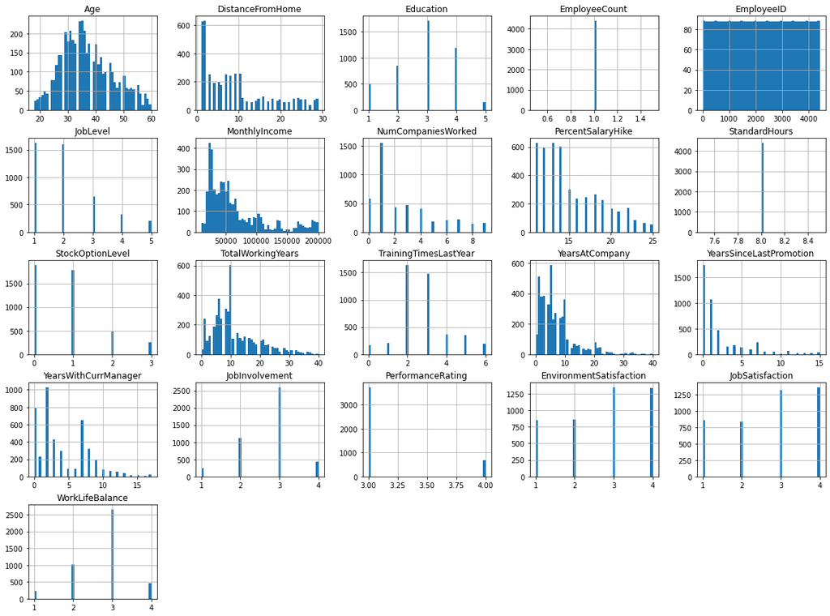

```python
dataset_without_in_out.hist(bins=50, figsize=(20,15))
plt.show()
```

Les colonnes suivantes ont donc été supprimées du dataset :

- EmployeeID
- EmployeeCount
- StandardHours
- Over18

#### C.3 Étude des horaires d'entrées / sorties

```python
dataset_with_in_out = dataset_with_in_out.apply(pd.to_datetime, format='%Y-%m-%d %H:%M:%S')
dataset_with_in_out.head()
```

|  | 2015-01-01_in | 2015-01-02_in | 2015-01-05_in | 2015-01-06_in | 2015-01-07_in | 2015-01-08_in | 2015-01-09_in | 2015-01-12_in | 2015-01-13_in | 2015-01-14_in | ... | 2015-12-18_out | 2015-12-21_out | 2015-12-22_out | 2015-12-23_out | 2015-12-24_out | 2015-12-25_out | 2015-12-28_out | 2015-12-29_out | 2015-12-30_out | 2015-12-31_out |
| --- | --- | --- | --- | --- | --- | --- | --- | --- | --- | --- | --- | --- | --- | --- | --- | --- | --- | --- | --- | --- | --- |
| 0 | NaT | 2015-01-02 09:43:45 | 2015-01-05 10:08:48 | 2015-01-06 09:54:26 | 2015-01-07 09:34:31 | 2015-01-08 09:51:09 | 2015-01-09 10:09:25 | 2015-01-12 09:42:53 | 2015-01-13 10:13:06 | NaT | ... | NaT | 2015-12-21 17:15:50 | 2015-12-22 17:27:51 | 2015-12-23 16:44:44 | 2015-12-24 17:47:22 | NaT | 2015-12-28 18:00:07 | 2015-12-29 17:22:30 | 2015-12-30 17:40:56 | 2015-12-31 17:17:33 |
| 1 | NaT | 2015-01-02 10:15:44 | 2015-01-05 10:21:05 | NaT | 2015-01-07 09:45:17 | 2015-01-08 10:09:04 | 2015-01-09 09:43:26 | 2015-01-12 10:00:07 | 2015-01-13 10:43:29 | NaT | ... | 2015-12-18 18:31:28 | 2015-12-21 17:34:16 | 2015-12-22 18:16:35 | 2015-12-23 17:38:18 | NaT | NaT | 2015-12-28 17:08:38 | 2015-12-29 17:54:46 | 2015-12-30 18:31:35 | 2015-12-31 17:40:58 |
| 2 | NaT | 2015-01-02 10:17:41 | 2015-01-05 09:50:50 | 2015-01-06 10:14:13 | 2015-01-07 09:47:27 | 2015-01-08 10:03:40 | 2015-01-09 10:05:49 | 2015-01-12 10:03:47 | 2015-01-13 10:21:26 | NaT | ... | 2015-12-18 17:02:23 | 2015-12-21 17:20:17 | 2015-12-22 16:32:50 | 2015-12-23 16:59:43 | 2015-12-24 16:58:25 | NaT | 2015-12-28 16:43:31 | 2015-12-29 17:09:56 | 2015-12-30 17:06:25 | 2015-12-31 17:15:50 |
| 3 | NaT | 2015-01-02 10:05:06 | 2015-01-05 09:56:32 | 2015-01-06 10:11:07 | 2015-01-07 09:37:30 | 2015-01-08 10:02:08 | 2015-01-09 10:08:12 | 2015-01-12 10:13:42 | 2015-01-13 09:53:22 | NaT | ... | 2015-12-18 17:55:23 | 2015-12-21 16:49:09 | 2015-12-22 17:24:00 | 2015-12-23 17:36:35 | 2015-12-24 16:48:21 | NaT | 2015-12-28 17:19:34 | 2015-12-29 16:58:16 | 2015-12-30 17:40:11 | 2015-12-31 17:09:14 |
| 4 | NaT | 2015-01-02 10:28:17 | 2015-01-05 09:49:58 | 2015-01-06 09:45:28 | 2015-01-07 09:49:37 | 2015-01-08 10:19:44 | 2015-01-09 10:00:50 | 2015-01-12 10:29:27 | 2015-01-13 09:59:32 | NaT | ... | 2015-12-18 17:52:48 | 2015-12-21 17:43:35 | 2015-12-22 18:07:57 | 2015-12-23 18:00:49 | 2015-12-24 17:59:22 | NaT | 2015-12-28 17:44:59 | 2015-12-29 18:47:00 | 2015-12-30 17:15:33 | 2015-12-31 17:42:14 |

5 rows × 522 columns

Moyenne du temps que chaque employés à passé sur son lieu de travail par jour entre le `01/01/2015` et le `31/12/2015`, en secondes :

```python
datetime_mean = datetime_sub.mean(axis = 1)
datetime_mean = datetime_mean.dt.total_seconds()
datetime_mean
```

```
0       26545.142241
1       27788.288136
2       25247.665289
3       25897.242553
4       28822.228571
            ...
4405    30680.197531
4406    21934.634855
4407    27743.874459
4408    34173.340249
4409    25160.211207
Length: 4410, dtype: float64
```

```python
final_dataset = dataset_without_in_out
final_dataset["MoyenneInOut"] = datetime_mean

final_dataset.info()
```

```
<class 'pandas.core.frame.DataFrame'>
Int64Index: 4410 entries, 0 to 4409
Data columns (total 24 columns):
 #   Column                   Non-Null Count  Dtype
---  ------                   --------------  -----
 0   Age                      4410 non-null   int64
 1   Attrition                4410 non-null   object
 2   BusinessTravel           4410 non-null   object
 3   Department               4410 non-null   object
 4   DistanceFromHome         4410 non-null   int64
 5   Education                4410 non-null   int64
 6   EducationField           4410 non-null   object
 7   JobLevel                 4410 non-null   int64
 8   JobRole                  4410 non-null   object
 9   MonthlyIncome            4410 non-null   int64
```

[output cut: 16 more lines]

#### C.4 Préparation de la variable cible

Avant de découper notre dataset en jeu d'entrainement et de test, nous allons préparer la variable cible `Attrition` pour qu'elle soit interprétable par notre model. En effet, cette varaible binaire contient deux valeurs qui sont "Yes" et "No". Nous allons ainsi convertir ces chaînes de caractères en chiffres.

```python
final_dataset['Attrition'] = final_dataset['Attrition'].replace(['Yes','No'], [1, 0])
```

Nous pouvons aussi vérifier les proportions de Yes et No dans notre `dataset` :

```python
print(final_dataset['Attrition'].value_counts())
print("Le nombre de Yes est de", (711/4410) * 100, "%")
```

```
0    3699
1     711
Name: Attrition, dtype: int64
Le nombre de Yes est de 16.122448979591837 %
```

#### C.5 Création des jeux d'entrainement et de test

Nous allons découper notre jeu de données en deux avec une séparation de 80%.

- Le `train_set` contiendra 80% de nos données. Le modèle de machine learning s'entrainera sur ces données.
- Le `test_set` contiendra 20% de nos données. Le modèle de machine sera testé sur ces données.

Nous allons faire un échantillonage stratifié sur la donnée `Attrition` pour que le `train_set` et le `test_set` possèdent les mêmes proportions de personnes qui sont restées et qui sont parties de l'entreprise.

Vérifions les proportions :

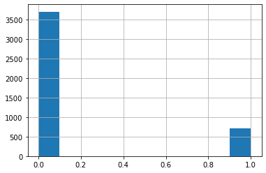

```python
final_dataset["Attrition"].hist()
```

On peut maintenant utiliser [`StratifiedShuffleSplit`](https://scikit-learn.org/stable/modules/generated/sklearn.model_selection.StratifiedShuffleSplit.html) pour échantillonner le jeu de données en respectant notre contrainte :

```python
from sklearn.model_selection import StratifiedShuffleSplit

split = StratifiedShuffleSplit(n_splits=1, test_size=0.2, random_state=42) #initialise le split

for train_index, test_index in split.split(final_dataset, final_dataset["Attrition"]):
    train_set = dataset_without_in_out.loc[train_index]
    test_set = dataset_without_in_out.loc[test_index]
```

Nous vérifions maintenant si les proportions ont bien été respectées :

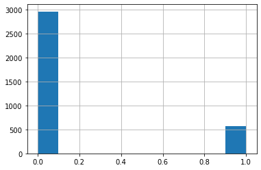

```python
train_set["Attrition"].hist()
```

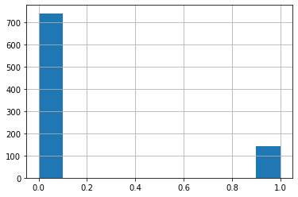

```python
test_set["Attrition"].hist()
```

Nos histrogrammes semblent avoir les mêmes proportions. Notre stratification a donc bien fonctionnée.

### D. Préparation des données d'entrainement pour les algorithmes de ML

Nous allons commencer par scinder le jeu de données d'entrainement. D'une part nous aurons, les variables-cibles, ou "labels", notées $Y$ et de l'autre, les "features" notées $X$.

```python
train_set_features = train_set.drop("Attrition", axis=1)
train_set_labels = train_set["Attrition"].copy()
```

#### D.1 Identifications des données numériques et qualitative

```python
train_set_features_num = train_set_features.select_dtypes(include=[np.number]) # recupère les données des colonnes numerique
train_set_features_cat = train_set_features.select_dtypes(exclude=[np.number]) # recupère les donnée des colonnes de categorie

train_set_features_num = list(train_set_features_num)
train_set_features_cat = list(train_set_features_cat)

train_set_features_cat
```

```
['BusinessTravel', 'Department', 'EducationField', 'JobRole']
```

#### D.2 Pipeline des données qualitatives

```python
from sklearn.pipeline import Pipeline
```

```python
from sklearn.preprocessing import OneHotEncoder

cat_pipeline = Pipeline([
    ('cat_encoder', OneHotEncoder())
])
```

#### D.2 Pipeline des données numériques

```python
from sklearn.impute import SimpleImputer
from sklearn.preprocessing import StandardScaler

num_pipeline = Pipeline([
        ('imputer', SimpleImputer(strategy="median")),
        ('std_scaler', StandardScaler()),
    ])
```

#### D.3 Pipeline de préparation des données

```python
from sklearn.compose import ColumnTransformer

full_pipeline = ColumnTransformer([
        ("num", num_pipeline, train_set_features_num),
        ("cat", cat_pipeline, train_set_features_cat),
    ])
```

```python
train_set_features_prepared = full_pipeline.fit_transform(train_set_features)
```

```python
train_set_features_cat = full_pipeline.named_transformers_['cat']['cat_encoder'].get_feature_names(train_set_features_cat)
train_set_features_cat = list(train_set_features_cat)
```

```python
train_set_features_prepared_pd = pd.DataFrame(
    train_set_features_prepared,
    columns = train_set_features_num + train_set_features_cat)

train_set_features_prepared_pd.head().style
```

|  | Age | DistanceFromHome | Education | JobLevel | MonthlyIncome | NumCompaniesWorked | PercentSalaryHike | StockOptionLevel | TotalWorkingYears | TrainingTimesLastYear | YearsAtCompany | YearsSinceLastPromotion | YearsWithCurrManager | JobInvolvement | PerformanceRating | EnvironmentSatisfaction | JobSatisfaction | WorkLifeBalance | MoyenneInOut | BusinessTravel_Non-Travel | BusinessTravel_Travel_Frequently | BusinessTravel_Travel_Rarely | Department_Human Resources | Department_Research & Development | Department_Sales | EducationField_Human Resources | EducationField_Life Sciences | EducationField_Marketing | EducationField_Medical | … |
| --- | --- | --- | --- | --- | --- | --- | --- | --- | --- | --- | --- | --- | --- | --- | --- | --- | --- | --- | --- | --- | --- | --- | --- | --- | --- | --- | --- | --- | --- | --- |
| 0 | 0.463140 | -1.016618 | 1.055180 | -0.969757 | -0.259638 | -0.679818 | -0.341374 | -0.939036 | -0.160786 | -0.615667 | 0.508815 | -0.677208 | 1.098882 | 1.797989 | -0.432065 | -0.661977 | 0.263919 | 0.337770 | 0.154623 | 0.000000 | 0.000000 | 1.000000 | 0.000000 | 0.000000 | 1.000000 | 0.000000 | 1.000000 | 0.000000 | 0.000000 | … |
| 1 | -0.306868 | -1.016618 | -1.876060 | -0.068228 | -0.801808 | 0.119915 | 2.102113 | -0.939036 | -0.676822 | 0.162575 | -1.149782 | -0.677208 | -1.146292 | 0.381440 | 2.314467 | 0.257856 | 1.169667 | 0.337770 | -0.460246 | 1.000000 | 0.000000 | 0.000000 | 0.000000 | 0.000000 | 1.000000 | 0.000000 | 0.000000 | 1.000000 | 0.000000 | … |
| 2 | -1.736884 | 0.087413 | -0.898980 | -0.969757 | -0.235080 | -0.679818 | -0.884371 | 0.234094 | -1.321867 | -0.615667 | -0.983923 | -0.677208 | -1.146292 | 0.381440 | -0.432065 | 0.257856 | -0.641828 | 0.337770 | -1.284879 | 0.000000 | 0.000000 | 1.000000 | 1.000000 | 0.000000 | 0.000000 | 1.000000 | 0.000000 | 0.000000 | 0.000000 | … |
| 3 | -0.966876 | -0.280597 | 0.078100 | -0.068228 | -0.742531 | -0.679818 | -0.341374 | -0.939036 | -1.321867 | 0.162575 | -0.983923 | -0.677208 | -1.146292 | 0.381440 | -0.432065 | -1.581810 | -0.641828 | 0.337770 | -1.059293 | 0.000000 | 1.000000 | 0.000000 | 0.000000 | 1.000000 | 0.000000 | 0.000000 | 1.000000 | 0.000000 | 0.000000 | … |
| 4 | 0.353139 | -1.016618 | 1.055180 | -0.068228 | 2.698904 | -0.279952 | -0.341374 | 0.234094 | -0.031777 | 0.162575 | -0.983923 | -0.677208 | -1.146292 | 0.381440 | -0.432065 | -1.581810 | -0.641828 | -1.094505 | -1.219655 | 0.000000 | 0.000000 | 1.000000 | 0.000000 | 1.000000 | 0.000000 | 0.000000 | 0.000000 | 0.000000 | 1.000000 | … |

Les diagrammes en boîtes (ou boites à moustache) nous permettent de visualiser la répartition des données au niveau de chaque features et mettre notamment en évidences la présebce de valeurs aberrantes. On remarque ici que malgré l'utilisation de méthodes permettent de réduire le nombre de valeurs aberrantes on obtient tout de même quelques valeurs aberrantes pour certaines features.

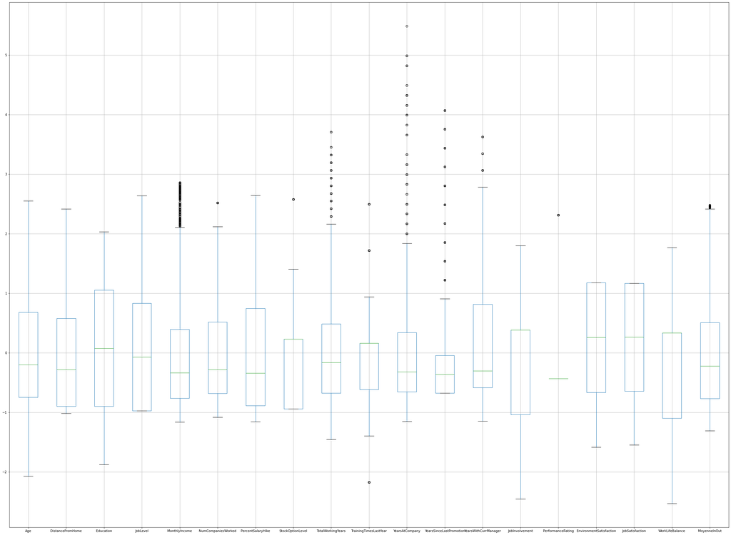

```python
train_set_features_prepared_pd.boxplot(train_set_features_num, figsize=(40,30))
```

#### D.4 Etude de corrélation

Maintenant que nos données qualitatif sont transformées, nous pouvons effectuer une étude de la corrélation sur la totalité des features (qualitatif + quantitatif).

Nous allons tout d'abord réassembler les features avec le label `Attrition`

```python
train_set_labels_pd = pd.DataFrame(train_set_labels)
result_train_set = train_set_features_prepared_pd.copy()

result_train_set["Attrition"] = train_set_labels_pd

print(train_set_labels_pd.shape)
print(train_set_features_prepared_pd.shape)
print(result_train_set.shape)

result_train_set.head().style
```

```
(3528, 1)
(3528, 40)
(3528, 41)
```

|  | Age | DistanceFromHome | Education | JobLevel | MonthlyIncome | NumCompaniesWorked | PercentSalaryHike | StockOptionLevel | TotalWorkingYears | TrainingTimesLastYear | YearsAtCompany | YearsSinceLastPromotion | YearsWithCurrManager | JobInvolvement | PerformanceRating | EnvironmentSatisfaction | JobSatisfaction | WorkLifeBalance | MoyenneInOut | BusinessTravel_Non-Travel | BusinessTravel_Travel_Frequently | BusinessTravel_Travel_Rarely | Department_Human Resources | Department_Research & Development | Department_Sales | EducationField_Human Resources | EducationField_Life Sciences | EducationField_Marketing | EducationField_Medical | … |
| --- | --- | --- | --- | --- | --- | --- | --- | --- | --- | --- | --- | --- | --- | --- | --- | --- | --- | --- | --- | --- | --- | --- | --- | --- | --- | --- | --- | --- | --- | --- |
| 0 | 0.463140 | -1.016618 | 1.055180 | -0.969757 | -0.259638 | -0.679818 | -0.341374 | -0.939036 | -0.160786 | -0.615667 | 0.508815 | -0.677208 | 1.098882 | 1.797989 | -0.432065 | -0.661977 | 0.263919 | 0.337770 | 0.154623 | 0.000000 | 0.000000 | 1.000000 | 0.000000 | 0.000000 | 1.000000 | 0.000000 | 1.000000 | 0.000000 | 0.000000 | … |
| 1 | -0.306868 | -1.016618 | -1.876060 | -0.068228 | -0.801808 | 0.119915 | 2.102113 | -0.939036 | -0.676822 | 0.162575 | -1.149782 | -0.677208 | -1.146292 | 0.381440 | 2.314467 | 0.257856 | 1.169667 | 0.337770 | -0.460246 | 1.000000 | 0.000000 | 0.000000 | 0.000000 | 0.000000 | 1.000000 | 0.000000 | 0.000000 | 1.000000 | 0.000000 | … |
| 2 | -1.736884 | 0.087413 | -0.898980 | -0.969757 | -0.235080 | -0.679818 | -0.884371 | 0.234094 | -1.321867 | -0.615667 | -0.983923 | -0.677208 | -1.146292 | 0.381440 | -0.432065 | 0.257856 | -0.641828 | 0.337770 | -1.284879 | 0.000000 | 0.000000 | 1.000000 | 1.000000 | 0.000000 | 0.000000 | 1.000000 | 0.000000 | 0.000000 | 0.000000 | … |
| 3 | -0.966876 | -0.280597 | 0.078100 | -0.068228 | -0.742531 | -0.679818 | -0.341374 | -0.939036 | -1.321867 | 0.162575 | -0.983923 | -0.677208 | -1.146292 | 0.381440 | -0.432065 | -1.581810 | -0.641828 | 0.337770 | -1.059293 | 0.000000 | 1.000000 | 0.000000 | 0.000000 | 1.000000 | 0.000000 | 0.000000 | 1.000000 | 0.000000 | 0.000000 | … |
| 4 | 0.353139 | -1.016618 | 1.055180 | -0.068228 | 2.698904 | -0.279952 | -0.341374 | 0.234094 | -0.031777 | 0.162575 | -0.983923 | -0.677208 | -1.146292 | 0.381440 | -0.432065 | -1.581810 | -0.641828 | -1.094505 | -1.219655 | 0.000000 | 0.000000 | 1.000000 | 0.000000 | 1.000000 | 0.000000 | 0.000000 | 0.000000 | 0.000000 | 1.000000 | … |

Nous pouvons désormais afficher la matrice de corrélation entre la totalité des features (et le label). Et ainsi observer les différents liens entre les features

```python
corr_matrix = result_train_set.corr(method='spearman')
corr_matrix_2 = result_train_set.corr(method='kendall')

corr_matrix.style.format("{:.2}").background_gradient(cmap=plt.get_cmap('coolwarm'))
```

|  | Age | DistanceFromHome | Education | JobLevel | MonthlyIncome | NumCompaniesWorked | PercentSalaryHike | StockOptionLevel | TotalWorkingYears | TrainingTimesLastYear | YearsAtCompany | YearsSinceLastPromotion | YearsWithCurrManager | JobInvolvement | PerformanceRating | EnvironmentSatisfaction | JobSatisfaction | WorkLifeBalance | MoyenneInOut | BusinessTravel_Non-Travel | BusinessTravel_Travel_Frequently | BusinessTravel_Travel_Rarely | Department_Human Resources | Department_Research & Development | Department_Sales | EducationField_Human Resources | EducationField_Life Sciences | EducationField_Marketing | EducationField_Medical | … |
| --- | --- | --- | --- | --- | --- | --- | --- | --- | --- | --- | --- | --- | --- | --- | --- | --- | --- | --- | --- | --- | --- | --- | --- | --- | --- | --- | --- | --- | --- | --- |
| Age | 1.0 | 0.0034 | -0.034 | -0.01 | -0.023 | 0.35 | -0.034 | -0.026 | 0.66 | -0.058 | 0.24 | 0.17 | 0.18 | 0.02 | -0.028 | 0.015 | 0.004 | 0.0021 | -0.005 | 0.00049 | -0.015 | 0.013 | -0.0091 | 0.022 | -0.019 | -0.046 | -0.017 | -0.031 | 0.027 | … |
| DistanceFromHome | 0.0034 | 1.0 | -0.016 | -0.025 | -0.019 | -0.041 | 0.04 | 0.013 | -0.0044 | 0.015 | 0.013 | 0.0052 | 0.029 | -0.032 | 0.039 | 0.022 | -0.019 | 0.0088 | 0.014 | -0.031 | 0.026 | -0.0019 | -0.032 | -0.0033 | 0.018 | 0.018 | 0.0025 | 0.019 | -0.0087 | … |
| Education | -0.034 | -0.016 | 1.0 | 0.039 | -0.0068 | -0.0086 | -0.034 | -0.0091 | 0.022 | 0.038 | 0.012 | 0.028 | 0.026 | -0.016 | -0.035 | -0.055 | 0.005 | -0.021 | 0.0023 | -0.0011 | 0.014 | -0.011 | 0.012 | -0.0056 | 0.00038 | -0.026 | 0.003 | -0.0032 | -0.024 | … |
| JobLevel | -0.01 | -0.025 | 0.039 | 1.0 | 0.036 | -0.013 | 0.041 | -0.034 | -0.031 | -0.031 | -0.043 | -0.041 | -0.039 | -0.024 | 0.019 | -0.029 | -0.019 | -0.018 | -0.0084 | -0.033 | -0.0052 | 0.026 | 0.021 | -0.043 | 0.035 | 0.0094 | 0.014 | 0.034 | -0.046 | … |
| MonthlyIncome | -0.023 | -0.019 | -0.0068 | 0.036 | 1.0 | -0.041 | 0.009 | 0.053 | -0.017 | 0.019 | 0.019 | 0.054 | 0.019 | 0.022 | 0.0051 | -0.004 | -0.0013 | 0.027 | -0.017 | 0.077 | -0.055 | -0.0034 | -0.021 | 0.056 | -0.049 | -0.0069 | 0.015 | -0.047 | 0.021 | … |
| NumCompaniesWorked | 0.35 | -0.041 | -0.0086 | -0.013 | -0.041 | 1.0 | 0.0054 | 0.04 | 0.32 | -0.018 | -0.17 | -0.064 | -0.15 | 0.021 | -0.0071 | 0.022 | -0.052 | -0.012 | -0.02 | 0.0027 | -0.035 | 0.028 | -0.042 | 0.05 | -0.033 | -0.028 | 0.0026 | 0.0035 | -0.011 | … |
| PercentSalaryHike | -0.034 | 0.04 | -0.034 | 0.041 | 0.009 | 0.0054 | 1.0 | 0.014 | -0.042 | -0.033 | -0.048 | -0.034 | -0.049 | -0.022 | 0.63 | -0.0017 | 0.025 | -0.038 | 0.029 | 0.035 | -0.0074 | -0.017 | -0.031 | 0.029 | -0.016 | -0.011 | -0.013 | -0.022 | 0.038 | … |
| StockOptionLevel | -0.026 | 0.013 | -0.0091 | -0.034 | 0.053 | 0.04 | 0.014 | 1.0 | 0.0084 | -0.059 | 0.0021 | 0.0091 | 0.0035 | 0.0047 | -0.036 | 0.0006 | 0.045 | 0.0021 | -0.014 | 0.0079 | -0.017 | 0.0093 | 0.014 | -0.028 | 0.023 | 0.003 | -0.046 | -0.0097 | 0.068 | … |
| TotalWorkingYears | 0.66 | -0.0044 | 0.022 | -0.031 | -0.017 | 0.32 | -0.042 | 0.0084 | 1.0 | -0.053 | 0.58 | 0.32 | 0.48 | -0.0095 | -0.013 | -0.0073 | -0.0079 | 0.0077 | -0.014 | -0.028 | -0.0081 | 0.025 | -0.048 | 0.062 | -0.042 | -0.062 | -0.0024 | -0.013 | 0.015 | … |
| TrainingTimesLastYear | -0.058 | 0.015 | 0.038 | -0.031 | 0.019 | -0.018 | -0.033 | -0.059 | -0.053 | 1.0 | -0.024 | 0.003 | -0.022 | -0.014 | -0.028 | 0.036 | -0.018 | -0.017 | -0.035 | 0.055 | -0.016 | -0.023 | -0.027 | 0.004 | 0.008 | -0.027 | 0.033 | -0.0017 | -0.0055 | … |
| YearsAtCompany | 0.24 | 0.013 | 0.012 | -0.043 | 0.019 | -0.17 | -0.048 | 0.0021 | 0.58 | -0.024 | 1.0 | 0.51 | 0.84 | -0.0088 | 0.0019 | 0.012 | 0.022 | 0.019 | -0.022 | -0.0018 | 0.017 | -0.014 | -0.046 | 0.03 | -0.0099 | -0.064 | 0.014 | -0.018 | -0.003 | … |
| YearsSinceLastPromotion | 0.17 | 0.0052 | 0.028 | -0.041 | 0.054 | -0.064 | -0.034 | 0.0091 | 0.32 | 0.003 | 0.51 | 1.0 | 0.45 | 0.018 | -0.01 | 0.031 | 0.016 | 0.0059 | -0.0067 | 0.0081 | 0.042 | -0.042 | -0.03 | 0.0086 | 0.005 | -0.055 | -0.018 | -0.03 | 0.05 | … |
| YearsWithCurrManager | 0.18 | 0.029 | 0.026 | -0.039 | 0.019 | -0.15 | -0.049 | 0.0035 | 0.48 | -0.022 | 0.84 | 0.45 | 1.0 | 0.0018 | 0.0029 | 0.002 | -0.0099 | 0.0041 | -0.014 | 0.012 | 0.0096 | -0.016 | -0.058 | 0.033 | -0.0082 | -0.08 | 0.015 | -0.02 | 0.0095 | … |
| JobInvolvement | 0.02 | -0.032 | -0.016 | -0.024 | 0.022 | 0.021 | -0.022 | 0.0047 | -0.0095 | -0.014 | -0.0088 | 0.018 | 0.0018 | 1.0 | 0.0043 | 0.015 | -0.0027 | -0.026 | -0.035 | -0.0099 | 0.019 | -0.0097 | 0.02 | -0.006 | -0.0029 | -0.0014 | 0.005 | 0.0088 | -0.029 | … |
| PerformanceRating | -0.028 | 0.039 | -0.035 | 0.019 | 0.0051 | -0.0071 | 0.63 | -0.036 | -0.013 | -0.028 | 0.0019 | -0.01 | 0.0029 | 0.0043 | 1.0 | 0.017 | 0.046 | -0.016 | 0.088 | 0.011 | -0.0046 | -0.0032 | -0.012 | 0.034 | -0.03 | -0.018 | 0.0036 | -0.028 | 0.015 | … |
| EnvironmentSatisfaction | 0.015 | 0.022 | -0.055 | -0.029 | -0.004 | 0.022 | -0.0017 | 0.0006 | -0.0073 | 0.036 | 0.012 | 0.031 | 0.002 | 0.015 | 0.017 | 1.0 | -0.0036 | 0.014 | 0.045 | 0.0049 | -0.007 | 0.0028 | 0.022 | 0.0027 | -0.013 | 0.021 | 0.021 | -0.03 | -0.003 | … |
| JobSatisfaction | 0.004 | -0.019 | 0.005 | -0.019 | -0.0013 | -0.052 | 0.025 | 0.045 | -0.0079 | -0.018 | 0.022 | 0.016 | -0.0099 | -0.0027 | 0.046 | -0.0036 | 1.0 | -0.026 | 0.039 | 0.016 | 0.045 | -0.05 | -0.0049 | -0.029 | 0.032 | -0.026 | 0.043 | 0.027 | -0.033 | … |
| WorkLifeBalance | 0.0021 | 0.0088 | -0.021 | -0.018 | 0.027 | -0.012 | -0.038 | 0.0021 | 0.0077 | -0.017 | 0.019 | 0.0059 | 0.0041 | -0.026 | -0.016 | 0.014 | -0.026 | 1.0 | -0.0016 | 0.017 | 0.018 | -0.027 | -0.018 | 0.002 | 0.0063 | 0.0083 | 0.015 | -0.028 | 0.024 | … |
| MoyenneInOut | -0.005 | 0.014 | 0.0023 | -0.0084 | -0.017 | -0.02 | 0.029 | -0.014 | -0.014 | -0.035 | -0.022 | -0.0067 | -0.014 | -0.035 | 0.088 | 0.045 | 0.039 | -0.0016 | 1.0 | -0.034 | 0.047 | -0.018 | -0.00074 | 0.028 | -0.028 | 0.028 | 0.0095 | -0.00099 | -0.034 | … |
| BusinessTravel_Non-Travel | 0.00049 | -0.031 | -0.0011 | -0.033 | 0.077 | 0.0027 | 0.035 | 0.0079 | -0.028 | 0.055 | -0.0018 | 0.0081 | 0.012 | -0.0099 | 0.011 | 0.0049 | 0.016 | 0.017 | -0.034 | 1.0 | -0.16 | -0.52 | -0.038 | 0.062 | -0.047 | -0.028 | 0.027 | -0.057 | 0.016 | … |
| BusinessTravel_Travel_Frequently | -0.015 | 0.026 | 0.014 | -0.0052 | -0.055 | -0.035 | -0.0074 | -0.017 | -0.0081 | -0.016 | 0.017 | 0.042 | 0.0096 | 0.019 | -0.0046 | -0.007 | 0.045 | 0.018 | 0.047 | -0.16 | 1.0 | -0.75 | -0.031 | -0.03 | 0.045 | -0.054 | -0.032 | 0.034 | 0.042 | … |
| BusinessTravel_Travel_Rarely | 0.013 | -0.0019 | -0.011 | 0.026 | -0.0034 | 0.028 | -0.017 | 0.0093 | 0.025 | -0.023 | -0.014 | -0.042 | -0.016 | -0.0097 | -0.0032 | 0.0028 | -0.05 | -0.027 | -0.018 | -0.52 | -0.75 | 1.0 | 0.052 | -0.015 | -0.0076 | 0.066 | 0.0099 | 0.0085 | -0.047 | … |
| Department_Human Resources | -0.0091 | -0.032 | 0.012 | 0.021 | -0.021 | -0.042 | -0.031 | 0.014 | -0.048 | -0.027 | -0.046 | -0.03 | -0.058 | 0.02 | -0.012 | 0.022 | -0.0049 | -0.018 | -0.00074 | -0.038 | -0.031 | 0.052 | 1.0 | -0.3 | -0.14 | 0.66 | -0.073 | -0.075 | -0.051 | … |
| Department_Research & Development | 0.022 | -0.0033 | -0.0056 | -0.043 | 0.056 | 0.05 | 0.029 | -0.028 | 0.062 | 0.004 | 0.03 | 0.0086 | 0.033 | -0.006 | 0.034 | 0.0027 | -0.029 | 0.002 | 0.028 | 0.062 | -0.03 | -0.015 | -0.3 | 1.0 | -0.9 | -0.2 | 0.13 | -0.47 | 0.18 | … |
| Department_Sales | -0.019 | 0.018 | 0.00038 | 0.035 | -0.049 | -0.033 | -0.016 | 0.023 | -0.042 | 0.008 | -0.0099 | 0.005 | -0.0082 | -0.0029 | -0.03 | -0.013 | 0.032 | 0.0063 | -0.028 | -0.047 | 0.045 | -0.0076 | -0.14 | -0.9 | 1.0 | -0.093 | -0.1 | 0.53 | -0.16 | … |
| EducationField_Human Resources | -0.046 | 0.018 | -0.026 | 0.0094 | -0.0069 | -0.028 | -0.011 | 0.003 | -0.062 | -0.027 | -0.064 | -0.055 | -0.08 | -0.0014 | -0.018 | 0.021 | -0.026 | 0.0083 | 0.028 | -0.028 | -0.054 | 0.066 | 0.66 | -0.2 | -0.093 | 1.0 | -0.12 | -0.049 | -0.098 | … |
| EducationField_Life Sciences | -0.017 | 0.0025 | 0.003 | 0.014 | 0.015 | 0.0026 | -0.013 | -0.046 | -0.0024 | 0.033 | 0.014 | -0.018 | 0.015 | 0.005 | 0.0036 | 0.021 | 0.043 | 0.015 | 0.0095 | 0.027 | -0.032 | 0.0099 | -0.073 | 0.13 | -0.1 | -0.12 | 1.0 | -0.28 | -0.57 | … |
| EducationField_Marketing | -0.031 | 0.019 | -0.0032 | 0.034 | -0.047 | 0.0035 | -0.022 | -0.0097 | -0.013 | -0.0017 | -0.018 | -0.03 | -0.02 | 0.0088 | -0.028 | -0.03 | 0.027 | -0.028 | -0.00099 | -0.057 | 0.034 | 0.0085 | -0.075 | -0.47 | 0.53 | -0.049 | -0.28 | 1.0 | -0.23 | … |
| EducationField_Medical | 0.027 | -0.0087 | -0.024 | -0.046 | 0.021 | -0.011 | 0.038 | 0.068 | 0.015 | -0.0055 | -0.003 | 0.05 | 0.0095 | -0.029 | 0.015 | -0.003 | -0.033 | 0.024 | -0.034 | 0.016 | 0.042 | -0.047 | -0.051 | 0.18 | -0.16 | -0.098 | -0.57 | -0.23 | 1.0 | … |
| EducationField_Other | -0.01 | -0.022 | 0.057 | 0.0066 | 0.011 | 0.0081 | 0.026 | -0.00063 | -0.043 | -0.054 | -0.0053 | -0.026 | -0.021 | 0.013 | 0.028 | -0.016 | -0.049 | 0.024 | 0.0062 | 0.018 | 0.026 | -0.035 | -0.0069 | 0.056 | -0.055 | -0.035 | -0.2 | -0.084 | -0.17 | … |
| EducationField_Technical Degree | 0.049 | -0.0015 | 0.0045 | 0.0051 | -0.016 | 0.016 | -0.031 | -0.022 | 0.057 | 0.012 | 0.035 | 0.029 | 0.036 | 0.019 | -0.015 | 0.0028 | 0.003 | -0.058 | 0.02 | -0.011 | -0.044 | 0.046 | -0.028 | 0.042 | -0.03 | -0.046 | -0.27 | -0.11 | -0.22 | … |
| JobRole_Healthcare Representative | -0.048 | -0.028 | -0.026 | 0.03 | -0.023 | 0.02 | 0.025 | 0.01 | -0.017 | -0.036 | 0.012 | 0.023 | -0.0045 | 0.012 | 0.027 | 0.037 | 0.0033 | -0.0067 | -0.011 | -0.0067 | -0.0025 | 0.0066 | -0.035 | 0.0065 | 0.0092 | -0.023 | 0.018 | -0.035 | -0.017 | … |
| JobRole_Human Resources | 0.017 | -0.00039 | 0.054 | 0.026 | -0.023 | 0.037 | -0.033 | -0.025 | 0.034 | -0.033 | 0.029 | 0.026 | 0.022 | -0.022 | -0.039 | 0.023 | 0.04 | -0.01 | -0.011 | 0.0083 | 0.019 | -0.022 | -0.019 | 0.014 | -0.0064 | -0.027 | 0.0025 | 0.022 | -0.012 | … |
| JobRole_Laboratory Technician | 0.022 | 0.059 | -0.076 | -0.035 | 0.017 | -0.0016 | 0.034 | 0.0097 | 0.018 | -0.031 | -0.011 | -0.017 | -0.0023 | 0.037 | 0.027 | 0.0038 | -0.0022 | -0.013 | -0.034 | -0.02 | -0.036 | 0.045 | -0.0023 | -0.013 | 0.014 | 0.023 | -0.014 | 0.033 | -0.00041 | … |
| JobRole_Manager | -0.0043 | -0.052 | 0.036 | 0.029 | -0.0094 | -0.004 | -0.0057 | -0.081 | -0.0048 | -0.014 | -0.023 | -0.004 | -0.05 | -0.0072 | 0.007 | 0.0036 | -0.0024 | 0.023 | -0.027 | -0.008 | -0.023 | 0.025 | -0.017 | 0.0027 | 0.005 | 0.024 | 0.018 | -0.021 | -0.0082 | … |
| JobRole_Manufacturing Director | -0.0037 | 0.012 | -0.0059 | -0.00095 | 0.046 | 0.0066 | -0.01 | 0.029 | -0.0069 | -0.011 | 0.012 | 0.045 | -0.0065 | -0.02 | -0.029 | -0.015 | 0.0052 | -0.012 | 0.022 | -0.0066 | 0.03 | -0.021 | 0.011 | -0.0013 | -0.0035 | 0.028 | 0.026 | -0.021 | -0.011 | … |
| JobRole_Research Director | 0.004 | -0.013 | 0.046 | 0.012 | 0.0088 | 0.019 | -0.022 | -0.011 | 0.018 | 0.024 | 0.0043 | -0.0039 | -0.014 | 0.081 | -0.024 | 0.012 | 0.021 | 0.02 | -0.011 | -0.0064 | 0.033 | -0.024 | -0.034 | 0.00091 | 0.015 | -0.0075 | 0.026 | 0.021 | -0.045 | … |
| JobRole_Research Scientist | 0.0022 | -0.011 | -0.0017 | 0.011 | -0.0094 | -0.022 | 0.003 | 0.019 | -0.006 | -0.017 | 0.019 | 0.014 | 0.036 | -0.042 | -0.015 | -0.0082 | -0.028 | -0.0096 | 0.011 | 0.022 | 0.029 | -0.039 | 0.0054 | -0.0046 | 0.0023 | -0.017 | -0.016 | 0.011 | 0.033 | … |
| JobRole_Sales Executive | 0.024 | -0.0067 | 0.0059 | -0.014 | 0.0095 | -0.017 | -0.044 | 0.026 | 0.022 | 0.07 | 0.013 | -0.021 | 0.04 | -0.0065 | -0.0042 | -0.03 | 0.0066 | 0.02 | 0.027 | 0.0079 | -0.0033 | -0.0024 | 0.041 | -0.01 | -0.008 | -0.018 | -0.024 | -0.0023 | 0.012 | … |
| JobRole_Sales Representative | -0.032 | 0.022 | 0.031 | -0.035 | -0.04 | -0.0041 | 0.054 | -0.026 | -0.068 | 0.032 | -0.069 | -0.057 | -0.065 | -0.02 | 0.039 | 0.00051 | -0.02 | -0.01 | 0.023 | 0.0066 | -0.041 | 0.031 | 0.017 | 0.026 | -0.035 | 0.017 | -0.0099 | -0.015 | 0.02 | … |
| Attrition | 4.7e-05 | 0.033 | -0.0062 | 0.02 | 0.015 | -0.015 | -0.0017 | -0.014 | -0.00064 | -0.022 | -0.0077 | 0.022 | -0.023 | -0.019 | -0.0063 | 0.021 | 0.0085 | 0.036 | 0.032 | -0.013 | 0.00081 | 0.0078 | 0.0078 | 0.011 | -0.015 | 0.032 | -0.029 | -0.012 | 0.011 | … |

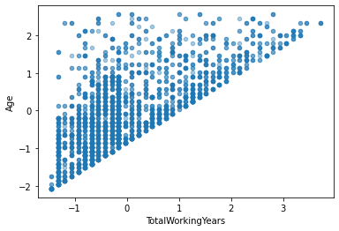

```python
result_train_set.plot(kind="scatter", x="TotalWorkingYears", y="Age", alpha=0.4,
    sharex=False)
```

Validons désormais certaines hypothèses de départ faites sur la corrélation entre certaines features :

- Hypothèse 1 : "Il exsiste une corrélation entre WorkLifeBalance et JobInvolvement"
- Hypothèse 2 : "Il exsiste une corrélation entre JobSatisfaction et EnvironmentSatisfaction"

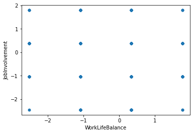

```python
result_train_set.plot(kind="scatter", x="WorkLifeBalance", y="JobInvolvement", alpha=0.4,
    sharex=False)
```

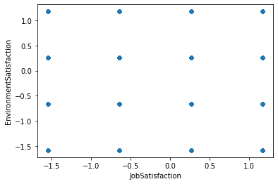

```python
result_train_set.plot(kind="scatter", x="JobSatisfaction", y="EnvironmentSatisfaction", alpha=0.4,
    sharex=False)
```

# 2. Choix d'un modèle de machine learning

Pour rappel, nôtre objectif est de proposer un model permettant de déterminer si un employée est susceptible de quitter ou non l'entreprise. Nous sommes donc à la recherche d'un modèle de classification binaire.

Voici donc la liste des modèles que nous avons retenus :

##### LogisticRegression :

La regression logistique est un algorithme de classification utilisé pour trouver la probabilité de succès et d'échec d'un événement. Il est utilisé lorsque le label est de nature binaire (0/1, Vrai / Faux, Oui / Non).

Dans la régression logistique, ce n’est pas la réponse binaire (malade/pas malade par exemple) qui est directement modélisée, mais la probabilité de réalisation d’une des deux modalités (être malade par exemple). Cette probabilité de réalisation ne peut pas être modélisée par une droite car celle-ci conduirait à des valeurs <0 ou >1. Ce qui est impossible puisqu’une probabilité est forcément bornée par 0 et 1.

Cette probabilité, est alors modélisée par une courbe sigmoïde, bornée par 0, et 1

[figure not shown]

Avantages

- Il peut s'étendre à plusieurs classes,
- La formation d'un modèle avec cet algorithme ne nécessite pas une puissance de calcul élevée
- Le temps d'apprentissage de l'algorithme de régression logistique s'avère bien inférieur à la plupart des algorithmes complexes
- La variance est faible.
- Les modèles logistiques peuvent être facilement mis à jour avec de nouvelles données en utilisant la descente de gradient stochastique.

Inconvénients

- Les problèmes non linéaires ne peuvent pas être résolus avec la régression logistique car elle a une surface de décision linéaire. Les données séparables linéairement sont rarement trouvées dans des cas concrets
- La régression logistique exige que les variables indépendantes soient linéairement liées au log des cotes (log (p / (1-p)) .
- Ne gère pas bien un grand nombre de variables catégorielles.
- Sensible aux valeurs aberrantes
- Nécessite un vaste ensemble de données

```python
from sklearn.linear_model import LogisticRegression
logistic_reg = LogisticRegression(random_state=42)
logistic_reg.fit(train_set_features_prepared, train_set_labels)
```

```
LogisticRegression(random_state=42)
```

##### Perceptron :

Le perceptron est un algorithme d'apprentissage supervisé de classifieurs binaires (c'est-à-dire séparant deux classes). Si le problème est linéairement séparable, un théorème assure que la règle du perceptron permet de trouver une séparatrice entre les deux classes.

[figure not shown]

Le perceptron peut être vu comme le type de réseau de neurones le plus simple. C'est un classifieur linéaire. Ce type de réseau neuronal ne contient aucun cycle. Dans sa version simplifiée, le perceptron est mono-couche et n'a qu'une seule sortie (booléenne) à laquelle toutes les entrées (booléennes) sont connectées.

```python
from sklearn.linear_model import Perceptron
perceptron = Perceptron(random_state=42)
perceptron.fit(train_set_features_prepared, train_set_labels)
```

```
Perceptron(random_state=42)
```

##### LinearSVC

```python
from sklearn.svm import LinearSVC
lin_svc = LinearSVC(random_state=42, max_iter=5000)
lin_svc.fit(train_set_features_prepared, train_set_labels)
```

```
LinearSVC(max_iter=5000, random_state=42)
```

##### GaussianNB

```python
from sklearn.naive_bayes import GaussianNB
gaus_nb = GaussianNB()
gaus_nb.fit(train_set_features_prepared, train_set_labels)
```

```
GaussianNB()
```

##### KNeighborsClassifier :

La "méthode des k plus proches voisins" est un algorithme de classification non supervisé qui se base sur la classe des voisins d'une entrée. L'objet en entrée est classifié selon le résultat majoritaire des classes d'appartenance de ses k plus proches voisins (on choisi généralement un k assez faible).

Avantages :

- Facile à implémenter pour des problèmes multi-classes ;
- Flexibilité sur les critère de distance :
  1. Distance euclidienne
  2. Distance de Hamming
  3. Distance de Minkowski
  4. Distance de Manhattan
- Modèle intuitif et simple ;
- Pas d'étape d'apprentissage (dû à l'étiquetage à partir de la classe de ses voisins).

Inconvénients :

- Algorithme lent à mesure que le jeu de données augmente ;
- Les caractéristiques (features) doivent être homogènes ;
- Optimisation du nombre de voisins complexe ;
- Traitement des valeurs manquantes intrinsèquement impossible.

Exemple graphique de comportement

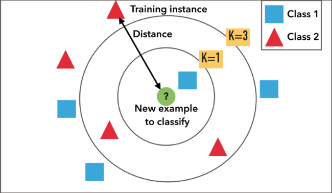

```python
from sklearn.neighbors import KNeighborsClassifier
k_neigh_clas = KNeighborsClassifier(n_neighbors=3)
k_neigh_clas.fit(train_set_features_prepared, train_set_labels)
```

```
KNeighborsClassifier(n_neighbors=3)
```

##### SVC :

```python
from sklearn.svm import SVC
svc = SVC(random_state=42)
svc.fit(train_set_features_prepared, train_set_labels)
```

```
SVC(random_state=42)
```

##### RandomForestClassifier :

```python
from sklearn.ensemble import RandomForestClassifier
forest_clas = RandomForestClassifier(random_state=42)
forest_clas.fit(train_set_features_prepared, train_set_labels)
```

```
RandomForestClassifier(random_state=42)
```

##### DecisionTreeClassifier :

L’apprentissage par arbre de décision désigne une méthode basée sur l'utilisation d'un arbre de décision comme modèle prédictif.

Dans ces structures d'arbre, les feuilles représentent les valeurs de la variable-cible et les embranchements correspondent à des combinaisons de variables d'entrée qui mènent à ces valeurs. En analyse de décision, un arbre de décision peut être utilisé pour représenter de manière explicite les décisions réalisées et les processus qui les amènent. En apprentissage et en fouille de données, un arbre de décision décrit les données mais pas les décisions elles-mêmes, l'arbre serait utilisé comme point de départ au processus de décision.

C'est une technique d'apprentissage supervisé : on utilise un ensemble de données pour lesquelles on connaît la valeur de la variable-cible afin de construire l'arbre (données dites étiquetées), puis on extrapole les résultats à l'ensemble des données de test.

[figure not shown]

Avantages

- Il est simple à comprendre - résultat interprétable : on aura donc aura donc plus de "maitrise" sur cette algorithme
- Temps d'execution raisonnable

Inconvénients

- Risque de sur-apprentissage (Overfitting) Pour atténuer ce défaut, on peut utiliser des ensembles d'arbres, comme des forêts aléatoires (RandomForest).

```python
from sklearn import tree

decision_tree_clas = tree.DecisionTreeClassifier()
decision_tree_clas.fit(train_set_features_prepared, train_set_labels)
```

```
DecisionTreeClassifier()
```

# 3. Mesure de la performance

### A. Introduction

Pour mesurer la performance de nos différents classifieur binaire, nous allons utiliser la `courbe en ROC` (Receiver Operating Characteristic). Cette courbe représente la sensibilité en fonction de (1 - spécificité). Plus en détails, cette courbe confronte le "taux de vrai positif" (*recall*) au "taux de faux positif"

Pour rappel :

- Un vrai positif est un résultat où le modèle prédit correctement la classe positive. De façon analogue, un vrai négatif est un résultat où le modèle prédit correctement la classe négative.
- Un faux positif est un résultat où le modèle prédit incorrectement la classe positive. Et un faux négatif est un résultat où le modèle prédit incorrectement la classe négative.
- Le taux de vrai positif est le ratio de positifs correctement classé, sa formule est :

$$ TPR = \frac{TP}{TP+FN} $$

- Le taux de faux positif est le ratio de positifs incorrectement classé, sa formule est :

$$ FPR = \frac{FP}{TN+FP} $$

### B. Récupération des décisions de chaque modèle

```python
from sklearn.model_selection import cross_val_predict
```

#### B.1 Prédiction par cross validation

Attention, nous avons deux méthode de prédiction selon le model utilisé.

##### Prédiction sur décision

```python
#LogisticRegression
logistic_reg_score = cross_val_predict(logistic_reg, train_set_features_prepared,
                             train_set_labels, cv=5, method="decision_function")

#Perceptron
perceptron_score = cross_val_predict(perceptron, train_set_features_prepared,
                             train_set_labels, cv=5, method="decision_function")

#LinearSVC
lin_svc_score = cross_val_predict(lin_svc, train_set_features_prepared,
                             train_set_labels, cv=5, method="decision_function")

#SVC
svc_score = cross_val_predict(svc, train_set_features_prepared,
                             train_set_labels, cv=5, method="decision_function")
```

##### Prédiction sur probabilité

```python
#GaussianNB
gaus_nb_score = cross_val_predict(gaus_nb, train_set_features_prepared,
                                      train_set_labels, cv=5, method="predict_proba")

#KNeighborsClassifier
k_neigh_clas_score = cross_val_predict(k_neigh_clas, train_set_features_prepared,
                                      train_set_labels, cv=5, method="predict_proba")

#RandomForestClassifier
forest_clas_score = cross_val_predict(forest_clas, train_set_features_prepared,
                                      train_set_labels, cv=5, method="predict_proba")

#DecisionTreeClassifier
decision_tree_clas_score = cross_val_predict(decision_tree_clas, train_set_features_prepared,
                                      train_set_labels, cv=5, method="predict_proba")
```

Nous representons en dataframe l'un de ces résultats, ici le `RandomForestClassifier`:

```python
forest_clas_score_pd = pd.DataFrame(data=forest_clas_score)
forest_clas_score_pd.head()
```

|  | 0 | 1 |
| --- | --- | --- |
| 0 | 0.93 | 0.07 |
| 1 | 0.93 | 0.07 |
| 2 | 0.10 | 0.90 |
| 3 | 0.13 | 0.87 |
| 4 | 0.95 | 0.05 |

Il nous faut calculer un score. Nous allons considérer la probabilité de la classe positive (deuxième colonne)

```python
gaus_nb_score = np.delete(gaus_nb_score, 0, axis=1)
k_neigh_clas_score = np.delete(k_neigh_clas_score, 0, axis=1)
forest_clas_score = np.delete(forest_clas_score, 0, axis=1)
decision_tree_clas_score = np.delete(decision_tree_clas_score, 0, axis=1)
```

#### B.2 Récupération des courbes ROC

```python
from sklearn.metrics import roc_curve
```

```python
#LogisticRegression
fpr_logistic_reg, tpr_logistic_reg, thresholds_logistic_reg = roc_curve(train_set_labels, logistic_reg_score)

#Perceptron
fpr_perceptron, tpr_perceptron, thresholds_perceptron = roc_curve(train_set_labels, perceptron_score)

#LinearSVC
fpr_lin_svc, tpr_lin_svc, thresholds_lin_svc = roc_curve(train_set_labels, lin_svc_score)

#GaussianNB
fpr_gaus_nb, tpr_gaus_nb, thresholds_gaus_nb = roc_curve(train_set_labels, gaus_nb_score)

#KNeighborsClassifier
fpr_k_neigh_clas, tpr_k_neigh_clas, thresholds_k_neigh_clas = roc_curve(train_set_labels, k_neigh_clas_score)

#SVC
fpr_svc, tpr_svc, thresholds_svc = roc_curve(train_set_labels, svc_score)

#RandomForestClassifier
fpr_forest_clas, tpr_forest_clas, thresholds_forest_clas = roc_curve(train_set_labels, forest_clas_score)

#DecisionTreeClassifier
fpr_decision_tree_clas, tpr_decision_tree_clas, thresholds_decision_tree_clas = roc_curve(train_set_labels, decision_tree_clas_score)
```

#### B.3 Fonction d'affichage d'une courbe ROC

```python
def plot_roc_curve(fpr, tpr, label=None):
    plt.plot(fpr, tpr, linewidth=2, label=label)
    plt.plot([0, 1], [0, 1], 'k--')
    plt.axis([0, 1, 0, 1])
    plt.xlabel('False Positive Rate', fontsize=16)
    plt.ylabel('True Positive Rate', fontsize=16)
```

#### B.4 Affichage des courbes ROC

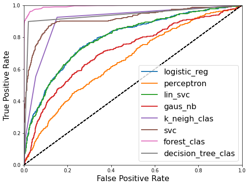

```python
plt.figure(figsize=(8, 6))
plot_roc_curve(fpr_logistic_reg, tpr_logistic_reg, "logistic_reg")
plot_roc_curve(fpr_perceptron, tpr_perceptron, "perceptron")
plot_roc_curve(fpr_lin_svc, tpr_lin_svc, "lin_svc")
plot_roc_curve(fpr_gaus_nb, tpr_gaus_nb, "gaus_nb")
plot_roc_curve(fpr_k_neigh_clas, tpr_k_neigh_clas, "k_neigh_clas")
plot_roc_curve(fpr_svc, tpr_svc, "svc")
plot_roc_curve(fpr_forest_clas, tpr_forest_clas, "forest_clas")
plot_roc_curve(fpr_decision_tree_clas, tpr_decision_tree_clas, "decision_tree_clas")
plt.legend(loc="lower right", fontsize=16)
plt.show()
```

##### Remarques :

La courbe `ROC` est un indicateur permettant de mesurer la performance d'un modèle de prédiction. (les paramètres sont variables selon l'objectif à prédire). Ici on utilise le taux de Vrai Positif (bonne "vrai" prédiction par le modèle - Attrition à Yes dans notre cas) et le taux de faux positif (le modèle à prédit Yes mais celui-ci s'est trompé). On cherche donc un modèle qui maximise le `TPR` et qui miniminise le `FPR` (on ne souhaite pas d'un modèle qui prédise qu'un l'employé à l'intention de partir alors que se n'est pas du tout le cas).

Nous souhaitons donc garder le modèle dont la courbe `ROC` se rapproche le plus possible de l'axe des ordonnées (TPR).On souhaite que la courbe `ROC` possède un point qui maximise au mieux le rapport `TPR/FPR`.

Apres analyse des différentes courbes `ROC` de chaque modèle on remarque deux canditats qui se distinguent et possèdent des performances très proche ("point optimal très proche") : Le `Random Forest Classifier` et le `Decision Tree Classifier`. Nous retiendrons donc pour la suite ces deux modèles et nous les départagerons apres variations de leurs hyperparamètres

#### B.5 Calculs des scores de chaque modèle

```python
from sklearn.metrics import roc_auc_score
roc_score_logistic_reg = roc_auc_score(train_set_labels, logistic_reg_score)
roc_score_perceptron = roc_auc_score(train_set_labels, perceptron_score)
roc_score_lin_svc = roc_auc_score(train_set_labels, lin_svc_score)
roc_score_gaus_nb = roc_auc_score(train_set_labels, gaus_nb_score)
roc_score_k_neigh_clas = roc_auc_score(train_set_labels, k_neigh_clas_score)
roc_score_svc = roc_auc_score(train_set_labels, svc_score)
roc_score_forest_clas = roc_auc_score(train_set_labels, forest_clas_score)
roc_score_decision_tree_clas = roc_auc_score(train_set_labels, decision_tree_clas_score)

print("logistic_reg : ", roc_score_logistic_reg)
print("perceptron : ", roc_score_perceptron)
print("lin_svc : ", roc_score_lin_svc)
print("gaus_nb : ", roc_score_gaus_nb)
print("k_neigh_clas : ", roc_score_k_neigh_clas)
print("svc : ", roc_score_svc)
print("forest_clas : ", roc_score_forest_clas)
print("decision_tree_clas : ", roc_score_decision_tree_clas)
```

```
logistic_reg :  0.7942745346329539
perceptron :  0.6529523879665327
lin_svc :  0.7935760608812531
gaus_nb :  0.7144148114447537
k_neigh_clas :  0.9061277411085658
svc :  0.9165157563443215
forest_clas :  0.9943528159598877
decision_tree_clas :  0.9390638075966148
```

#### B.4 Calcul de précision et recall des meilleurs modèles

```python
forest_clas_labels_pred = cross_val_predict(forest_clas, train_set_features_prepared, train_set_labels, cv=5)
decision_tree_clas_labels_pred = cross_val_predict(decision_tree_clas, train_set_features_prepared, train_set_labels, cv=5)
```

```python
from sklearn.metrics import precision_score, recall_score
print("\nPrécision forest_clas :", precision_score(train_set_labels, forest_clas_labels_pred))
print("Recall forest_clas :", recall_score(train_set_labels, forest_clas_labels_pred))

print("\nPrécision decision_tree_clas :", precision_score(train_set_labels, decision_tree_clas_labels_pred))
print("Recall decision_tree_clas :", recall_score(train_set_labels, decision_tree_clas_labels_pred))
```

```
Précision forest_clas : 0.9941060903732809
Recall forest_clas : 0.8892794376098418

Précision decision_tree_clas : 0.902135231316726
Recall decision_tree_clas : 0.8910369068541301
```

# 3. Paramétrage des meilleurs modèles

Nos deux meilleurs modèles étant maintenant choisit, nous allons chercher le meilleur paramétrage pour ceux-ci.

```python
from sklearn.model_selection import RandomizedSearchCV
from scipy.stats import randint
```

### A. RandomForestClassifier

```python
param_distribs_forest_clas = {
        'n_estimators': randint(low=1, high=200),
        'max_features': randint(low=1, high=8),
    }

forest_clas_param = RandomizedSearchCV(forest_clas, param_distribs_forest_clas, cv=5,
                           scoring='roc_auc', n_iter=10, return_train_score=True)

forest_clas_param.fit(train_set_features_prepared, train_set_labels)
```

```
RandomizedSearchCV(cv=5, estimator=RandomForestClassifier(random_state=42),
                   param_distributions={'max_features': <scipy.stats._distn_infrastructure.rv_frozen object at 0x00000268156108B0>,
                                        'n_estimators': <scipy.stats._distn_infrastructure.rv_frozen object at 0x00000268158F6880>},
                   return_train_score=True, scoring='roc_auc')
```

```python
best_estimator_forest_clas = forest_clas_param.best_estimator_
best_estimator_forest_clas
```

```
RandomForestClassifier(max_features=2, n_estimators=150, random_state=42)
```

### B. DecisionTreeClassifier

```python
param_distribs_decision_tree_clas = {
    'criterion': ['gini','entropy'],
    'max_depth': np.arange(1, 100),}

decision_tree_clas_param = RandomizedSearchCV(decision_tree_clas, param_distribs_decision_tree_clas, cv=5,
                            scoring='roc_auc', n_iter=10, return_train_score=True)

decision_tree_clas_param.fit(train_set_features_prepared, train_set_labels)
```

```
RandomizedSearchCV(cv=5, estimator=DecisionTreeClassifier(),
                   param_distributions={'criterion': ['gini', 'entropy'],
                                        'max_depth': array([ 1,  2,  3,  4,  5,  6,  7,  8,  9, 10, 11, 12, 13, 14, 15, 16, 17,
       18, 19, 20, 21, 22, 23, 24, 25, 26, 27, 28, 29, 30, 31, 32, 33, 34,
       35, 36, 37, 38, 39, 40, 41, 42, 43, 44, 45, 46, 47, 48, 49, 50, 51,
       52, 53, 54, 55, 56, 57, 58, 59, 60, 61, 62, 63, 64, 65, 66, 67, 68,
       69, 70, 71, 72, 73, 74, 75, 76, 77, 78, 79, 80, 81, 82, 83, 84, 85,
       86, 87, 88, 89, 90, 91, 92, 93, 94, 95, 96, 97, 98, 99])},
                   return_train_score=True, scoring='roc_auc')
```

```python
best_estimator_decision_tree_clas = decision_tree_clas_param.best_estimator_
best_estimator_decision_tree_clas
```

```
DecisionTreeClassifier(max_depth=52)
```

# 4. Test des modèles

Nos deux modèles sont maintenant prêt à être testés sur le `test_set`. Nous allons dans un premier temps isoler la donnée "recherchée" du test_set, à savoir `Attrition` puis nous allons appliquer notre pipeline de transformation de données sur nos `features`.

```python
test_set_features = test_set.drop("Attrition", axis=1)
test_set_labels = test_set["Attrition"].copy()
test_set_features_prepared = full_pipeline.transform(test_set_features)
```

Affichons les scores qu'obtiennent nos modèles sur le `test_set`

```python
print("forest_clas_best_score : ", best_estimator_forest_clas.score(test_set_features_prepared, test_set_labels))
print("decision_tree_clas_best_score : ", best_estimator_decision_tree_clas.score(test_set_features_prepared, test_set_labels))
```

```
forest_clas_best_score :  0.9965986394557823
decision_tree_clas_best_score :  0.9920634920634921
```

Wow 99% de réussite, ce sonbt de très bon score. Affichons maintenant les matrices de confusion pour le `test_set`.

```python
from sklearn.metrics import confusion_matrix

forest_clas_test_set_labels_pred = best_estimator_forest_clas.predict(test_set_features_prepared)
decision_tree_clas_test_set_labels_pred = best_estimator_decision_tree_clas.predict(test_set_features_prepared)
```

```python
conf_mx_forest_clas = confusion_matrix(test_set_labels, forest_clas_test_set_labels_pred)
conf_mx_forest_clas_pd = pd.DataFrame(data=conf_mx_forest_clas)
print("conf_mx_forest_clas : ")
conf_mx_forest_clas_pd
```

```
conf_mx_forest_clas :
```

|  | 0 | 1 |
| --- | --- | --- |
| 0 | 740 | 0 |
| 1 | 3 | 139 |

Grace à cette matrice, nous voyons que notre modèle a prédit que 3 personnes n'allaient pas partir, alors que c'est le cas. Cette matrice est donc plutôt bonne car nous avions au total 142 personnes qui sont parties

```python
conf_mx_decision_tree_clas = confusion_matrix(test_set_labels, decision_tree_clas_test_set_labels_pred)
conf_mx_decision_tree_clas_pd = pd.DataFrame(data=conf_mx_decision_tree_clas)
print("conf_mx_decision_tree_clas : ")
conf_mx_decision_tree_clas_pd
```

```
conf_mx_decision_tree_clas :
```

|  | 0 | 1 |
| --- | --- | --- |
| 0 | 737 | 3 |
| 1 | 4 | 138 |

Ainsi, le meilleur modèle de prédiction correspondant au problème de l'entreprise est le `RandomForestClassifier`

# 5. Étude des résultats

```python
feature_importances_forest_clas = best_estimator_forest_clas.feature_importances_
feature_importances_forest_clas
```

```
array([0.07546846, 0.05164814, 0.03200454, 0.02934064, 0.06221947,
       0.04154075, 0.04408451, 0.02442828, 0.06522754, 0.03329901,
       0.05850391, 0.03399032, 0.04686987, 0.02528471, 0.00929662,
       0.03710929, 0.03456039, 0.02997122, 0.08494816, 0.0071209 ,
       0.01614554, 0.01156376, 0.00724192, 0.01044512, 0.00978756,
       0.00520719, 0.01260582, 0.00617739, 0.01242357, 0.00516523,
       0.00544923, 0.00706945, 0.00414472, 0.01074172, 0.00570829,
       0.00635032, 0.0066767 , 0.01122423, 0.01234619, 0.00660933])
```

```python
sorted(zip(feature_importances_forest_clas, train_set_features_num + train_set_features_cat), reverse=True)
```

```
[(0.08494815919797456, 'MoyenneInOut'),
 (0.07546846345488978, 'Age'),
 (0.0652275356733672, 'TotalWorkingYears'),
 (0.06221946541796393, 'MonthlyIncome'),
 (0.058503906656387696, 'YearsAtCompany'),
 (0.05164814155938681, 'DistanceFromHome'),
 (0.04686986903715687, 'YearsWithCurrManager'),
 (0.044084505314574036, 'PercentSalaryHike'),
 (0.041540752596663344, 'NumCompaniesWorked'),
 (0.037109286228262234, 'EnvironmentSatisfaction'),
 (0.03456039070106015, 'JobSatisfaction'),
 (0.03399031906362058, 'YearsSinceLastPromotion'),
 (0.033299009693461515, 'TrainingTimesLastYear'),
 (0.032004542526563186, 'Education'),
 (0.02997122086240382, 'WorkLifeBalance'),
 (0.02934063820893313, 'JobLevel'),
 (0.025284706872498487, 'JobInvolvement'),
 (0.02442828249349494, 'StockOptionLevel'),
 (0.01614553938895108, 'BusinessTravel_Travel_Frequently'),
 (0.012605815102952134, 'EducationField_Life Sciences'),
 (0.012423572645089961, 'EducationField_Medical'),
 (0.012346186084978622, 'JobRole_Sales Executive'),
 (0.01156375881496591, 'BusinessTravel_Travel_Rarely'),
 (0.011224231984377839, 'JobRole_Research Scientist'),
 (0.010741718551708293, 'JobRole_Laboratory Technician'),
 (0.010445118912408952, 'Department_Research & Development'),
 (0.009787561150330332, 'Department_Sales'),
 (0.009296621044743842, 'PerformanceRating'),
 (0.007241920439648291, 'Department_Human Resources'),
 (0.007120903491758009, 'BusinessTravel_Non-Travel'),
 (0.0070694513412104315, 'JobRole_Healthcare Representative'),
 (0.006676704488172662, 'JobRole_Research Director'),
 (0.0066093274456000516, 'JobRole_Sales Representative'),
 (0.006350321171584184, 'JobRole_Manufacturing Director'),
 (0.006177394185130718, 'EducationField_Marketing'),
 (0.005708290801495584, 'JobRole_Manager'),
 (0.00544922740475616, 'EducationField_Technical Degree'),
 (0.005207194270527471, 'EducationField_Human Resources'),
 (0.005165230565228017, 'EducationField_Other'),
 (0.004144715155719169, 'JobRole_Human Resources')]
```

On remarque que la feature `MoyenneInOut` est celle qui influence le plus `Attrition`. Etudions comment le temps de travail moyen sur l'année 2015 d'un salarié impacte sa prise de décision concernant son choix de rester au sein de l'entreprise ou bien de partir pour l'année 2016. Nous comparons une variable binaire avec une variable discrète.

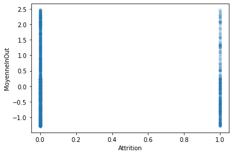

```python
result_train_set.plot(kind="scatter", x="Attrition", y="MoyenneInOut", alpha=0.1,
    sharex=False)
```

Le label attrition étant binaire (Oui ou Non), le graphique est donc partagé en deux catégories

- 0 - le salarié souhaite continuer à travailler pour l'entreprise pour l'année 2016
- 1 - le salarié à décidé de partir de l'entreprise durant l'année 2016